# Round 2 for Data Intake Method

Dan Johnson

11/24/2018

## Preparing and Pre-Checking the Initial Dataset

Call in tidyverse, other libraries.

```r
library(tidyverse)
library(tidytext)
```

```r
library(dplyr)
library(tidyr)
library(ggplot2)
library(scales)
```

```r
# Read CSV.
base_data <- read_csv(file='data/coded_full_comments_dataset_Spring18.csv')
head(base_data)
```

```
## # A tibble: 6 x 28
##   unique.record report.id  sort report.title student course ta    lab
##   <chr>         <chr>     <dbl> <chr>        <chr>    <dbl> <chr> <chr>
## 1 Sp18.00001    R_0fanqH…     1 R_1mmvZoqYc… vealmp…    113 Robb… allo…
## 2 Sp18.00002    R_0fanqH…     2 R_1mmvZoqYc… vealmp…    113 Robb… allo…
## 3 Sp18.00003    R_0fanqH…     3 R_1mmvZoqYc… vealmp…    113 Robb… allo…
## 4 Sp18.00004    R_0fanqH…     3 R_1mmvZoqYc… vealmp…    113 Robb… allo…
## 5 Sp18.00005    R_0fanqH…     4 R_1mmvZoqYc… vealmp…    113 Robb… allo…
## 6 Sp18.00006    R_0fanqH…     5 R_1mmvZoqYc… vealmp…    113 Robb… allo…
## # ... with 20 more variables: tag <chr>, type.TA <chr>, grade.TA <chr>,
## #   grading.time <chr>, Rank <dbl>, hypothesis.ok <chr>, data.ok <chr>,
## #   citation.ok <chr>, interpretation.ok <chr>, organization.ok <chr>,
## #   techflaws.ok <chr>, writing.ok <chr>, comments.incorporated <chr>,
## #   ta.comment <chr>, code.subject <chr>, code.structure <chr>,
## #   code.locus <chr>, code.scope <chr>, code.tone <chr>, code.notes <lgl>
```

```r
# Isolate table rows to compare.
frequency2 <- filter(base_data, code.subject=="1. Basic Criteria" |code.subject=="2. Writing Quality"|code.subject=="3. Technical and Scientific"|code.subject=="4. Logic and Thinking")
#Reduce larger dataframe to just 4 required columns of data
frequency.subcolumns <- frequency2 %>% select(1, 22:24)
```

Next block tokenizes the TA comments as individual words and removes stop words.

```r
# Tokenize phrases, remove stop words listed in standard reference file.
base_data_tokenized <- frequency.subcolumns %>%
  unnest_tokens(word,ta.comment) %>%
  anti_join(stop_words)
```

At this point the four-column tibble has “UniqueID” in column 1, “code.subject” in column 2, “code.structure” in column 3, and the unnested “words” in column 4. All four columns are class = “character”. Stop words from the R “stop_words” data file have been removed.

```r
#Groups by code.subject, calculated proportional frequency in each group.
#Final step creates 4 columns; 2 are for 1. Basic Criteria data, others for
#remaining three data sets. Stats will compare 1. BC against others.
base_data_tokenized_sorted <- base_data_tokenized %>%
  group_by(code.subject) %>%
  count(code.subject, word, sort=TRUE) %>%
  mutate(proportion = n / sum(n)) %>%
  select(-n) %>%
  spread(code.subject, proportion) %>%
  gather(code.subject, proportion, `2. Writing Quality`:`3. Technical and Scientific`:`4. Logic and Thinking`)
```

“base_data_tokenized_sorted” is the final 4-column dataframe with individual words in column 1, “1. Basic Criteria” proportion in column 2, “code.subject” in column 3, and “proportion” in column 4. Columns 1 and 3 are class = “character”, 2 and 4 are numeric ranges.

This structure is needed in order to compare word (in Column 1) frequencies for 1. Basic Criteria (Column 2) as Y values against the frequencies of those same words (in Column 4) as X axes. Which subset of the X values to use is coded in Column 3.

## Analysis

These three steps determine the Pearson correlation between the frequency of words in Basic Criteria versus the other three groups.

```r
cor.test(data = base_data_tokenized_sorted[base_data_tokenized_sorted$code.subject == "2. Writing Quality",],
         ~ proportion + `1. Basic Criteria`)
```

```
##
##  Pearson's product-moment correlation
##
## data:  proportion and 1. Basic Criteria
## t = 7.0975, df = 260, p-value = 1.208e-11
## alternative hypothesis: true correlation is not equal to 0
## 95 percent confidence interval:
##  0.2961356 0.4996585
## sample estimates:
##       cor
## 0.4028653
```

```r
cor.test(data = base_data_tokenized_sorted[base_data_tokenized_sorted$code.subject == "3. Technical and Scientific",],
         ~ proportion + `1. Basic Criteria`)
```

```
##
##  Pearson's product-moment correlation
##
## data:  proportion and 1. Basic Criteria
## t = 4.7955, df = 264, p-value = 2.715e-06
## alternative hypothesis: true correlation is not equal to 0
## 95 percent confidence interval:
##  0.1685369 0.3900623
## sample estimates:
##       cor
## 0.2830706
```

```r
cor.test(data = base_data_tokenized_sorted[base_data_tokenized_sorted$code.subject == "4. Logic and Thinking",],
         ~ proportion + `1. Basic Criteria`)
```

```
##
##  Pearson's product-moment correlation
##
## data:  proportion and 1. Basic Criteria
## t = 6.9695, df = 219, p-value = 3.688e-11
## alternative hypothesis: true correlation is not equal to 0
## 95 percent confidence interval:
##  0.3116206 0.5283333
## sample estimates:
##       cor
## 0.4260697
```

If the words used by TAs in comments are not different between the categories, there should be fairly high correlation.

The final step generates a graphical comparison of word frequencies.

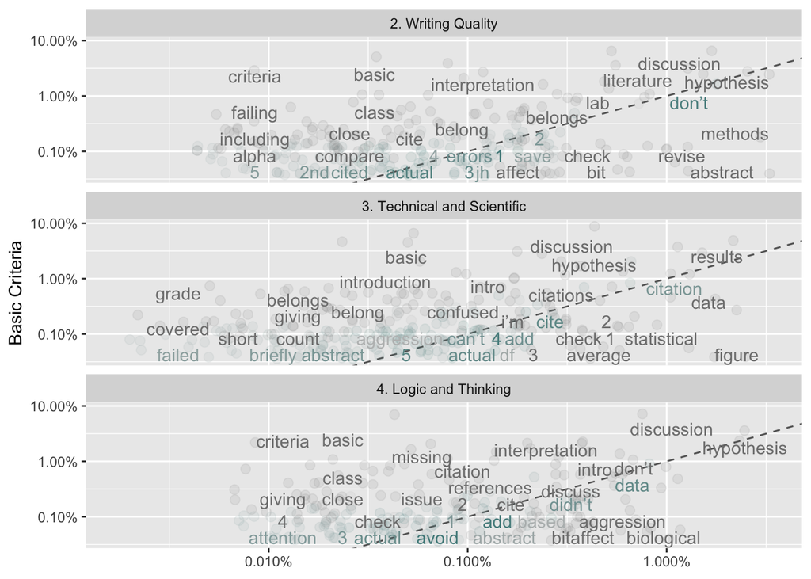

```r
# Expect a warning about rows with missing values being removed
ggplot(base_data_tokenized_sorted, aes(x = proportion, y = `1. Basic Criteria`, color = abs(`1. Basic Criteria` - proportion))) +
  geom_abline(color = "gray40", lty = 2) +
  geom_jitter(alpha = 0.1, size = 2.5, width = 0.3, height = 0.3) +
  geom_text(aes(label = word), check_overlap = TRUE, vjust = 1.5) +
  scale_x_log10(labels = percent_format()) +
  scale_y_log10(labels = percent_format()) +
  scale_color_gradient(limits = c(0, 0.001), low = "darkslategray4", high = "gray75") +
  facet_wrap(~code.subject, ncol = 1) +
  theme(legend.position="none") +
  labs(y = "Basic Criteria", x = NULL)
```

```r
  ggsave("plot.png", width = 6, height = 10)
```

If the words used by TAs in comments are not different between the categories, the slopes of the lines in the three comparison graphs should be close to 1, with intercepts approaching zero.